# Estimating time-varying networks from cryptocurrency dataset

For this example, download and extract folder *cryptocurrency_example.zip* to your R directory. Follow this by setting your working directory to it

```r
setwd("./cryptocurrency_example")
```

For this notebook, we use packages

```r
library(quantmod)
library(cmdstanr)
library(igraph)
library(posterior)
```

The functions used for edge selection and performance evaluation can be found in *btvn_functions.R*.

```r
source("btvn_functions.R")
```

Loading the data and creating the two datasets: Normalization by month and Normalization for the whole period

```r
crypto = c("BTC",
"WBTC",
"WSTETH",
"ETH",
"STETH",
"WETH",
"BNB",
"BCH",
"SOL",
"LTC",
"AVAX",
"LINK",
"LEO",
"TON11419",
"NEAR",
"DOT",
"USDC",
"DAI",
"USDT",
"XRP")

crypto = paste0(crypto, "-USD")

Data2 = c()

for(cr in crypto){

  A = list(Symbols = cr,
           auto.assign = FALSE,
           from = "2022-01-01",
           to = "2024-06-30")

  a = do.call("getSymbols", A)

  Data2 = cbind(Data2, a[, 4]) # Closing prices

}

#monthly
crypto_data_list_monthly <- create_list_by_month2(Data2,c(2022,2023,2024),
                 list(c("01","02","03","04","05","06","07","08","09",10,11,12),
                      c("01","02","03","04","05","06","07","08","09",10,11,12),
                      c("01","02","03","04","05","06")), scale = T)
#whole period
crypto_data_list_whole <- create_list_by_month2(scale(Data2),c(2022,2023,2024),
                 list(c("01","02","03","04","05","06","07","08","09",10,11,12),
                      c("01","02","03","04","05","06","07","08","09",10,11,12),
                      c("01","02","03","04","05","06")), scale = F)

sample_sizes <- c()
for (i in 1:30) {
  sample_sizes[i] <- dim(crypto_data_list_monthly[[i]])[[1]]
}
```

```r
data_crypto_monthly <- list( T=30, N=sample_sizes, M=20,
                          elet1 =as.matrix(crypto_data_list_monthly[[1]]),
                          elet2 =as.matrix(crypto_data_list_monthly[[2]]),
                          elet3 =as.matrix(crypto_data_list_monthly[[3]]),
                          elet4 =as.matrix(crypto_data_list_monthly[[4]]),
                          elet5 =as.matrix(crypto_data_list_monthly[[5]]),
                          elet6 =as.matrix(crypto_data_list_monthly[[6]]),
                          elet7 =as.matrix(crypto_data_list_monthly[[7]]),
                          elet8 =as.matrix(crypto_data_list_monthly[[8]]),
                          elet9 =as.matrix(crypto_data_list_monthly[[9]]),
                          elet10=as.matrix(crypto_data_list_monthly[[10]]),
                          elet11=as.matrix(crypto_data_list_monthly[[11]]),
                          elet12=as.matrix(crypto_data_list_monthly[[12]]),
                          elet13=as.matrix(crypto_data_list_monthly[[13]]),
                          elet14=as.matrix(crypto_data_list_monthly[[14]]),
                          elet15=as.matrix(crypto_data_list_monthly[[15]]),
                          elet16=as.matrix(crypto_data_list_monthly[[16]]),
                          elet17=as.matrix(crypto_data_list_monthly[[17]]),
                          elet18=as.matrix(crypto_data_list_monthly[[18]]),
                          elet19=as.matrix(crypto_data_list_monthly[[19]]),
                          elet20=as.matrix(crypto_data_list_monthly[[20]]),
                          elet21=as.matrix(crypto_data_list_monthly[[21]]),
                          elet22=as.matrix(crypto_data_list_monthly[[22]]),
                          elet23=as.matrix(crypto_data_list_monthly[[23]]),
                          elet24=as.matrix(crypto_data_list_monthly[[24]]),
                          elet25=as.matrix(crypto_data_list_monthly[[25]]),
                          elet26=as.matrix(crypto_data_list_monthly[[26]]),
                          elet27=as.matrix(crypto_data_list_monthly[[27]]),
                          elet28=as.matrix(crypto_data_list_monthly[[28]]),
                          elet29=as.matrix(crypto_data_list_monthly[[29]]),
                          elet30=as.matrix(crypto_data_list_monthly[[30]]),
                          theta=0.011)

data_crypto_whole <- list( T=30, N=sample_sizes, M=20,
                        elet1 =as.matrix(crypto_data_list_whole[[1]]),
                        elet2 =as.matrix(crypto_data_list_whole[[2]]),
                        elet3 =as.matrix(crypto_data_list_whole[[3]]),
                        elet4 =as.matrix(crypto_data_list_whole[[4]]),
                        elet5 =as.matrix(crypto_data_list_whole[[5]]),
                        elet6 =as.matrix(crypto_data_list_whole[[6]]),
                        elet7 =as.matrix(crypto_data_list_whole[[7]]),
                        elet8 =as.matrix(crypto_data_list_whole[[8]]),
                        elet9 =as.matrix(crypto_data_list_whole[[9]]),
                        elet10=as.matrix(crypto_data_list_whole[[10]]),
                        elet11=as.matrix(crypto_data_list_whole[[11]]),
                        elet12=as.matrix(crypto_data_list_whole[[12]]),
                        elet13=as.matrix(crypto_data_list_whole[[13]]),
                        elet14=as.matrix(crypto_data_list_whole[[14]]),
                        elet15=as.matrix(crypto_data_list_whole[[15]]),
                        elet16=as.matrix(crypto_data_list_whole[[16]]),
                        elet17=as.matrix(crypto_data_list_whole[[17]]),
                        elet18=as.matrix(crypto_data_list_whole[[18]]),
                        elet19=as.matrix(crypto_data_list_whole[[19]]),
                        elet20=as.matrix(crypto_data_list_whole[[20]]),
                        elet21=as.matrix(crypto_data_list_whole[[21]]),
                        elet22=as.matrix(crypto_data_list_whole[[22]]),
                        elet23=as.matrix(crypto_data_list_whole[[23]]),
                        elet24=as.matrix(crypto_data_list_whole[[24]]),
                        elet25=as.matrix(crypto_data_list_whole[[25]]),
                        elet26=as.matrix(crypto_data_list_whole[[26]]),
                        elet27=as.matrix(crypto_data_list_whole[[27]]),
                        elet28=as.matrix(crypto_data_list_whole[[28]]),
                        elet29=as.matrix(crypto_data_list_whole[[29]]),
                        elet30=as.matrix(crypto_data_list_whole[[30]]),
                        theta=0.011)
```

Model compilation

```r
crypto_main_m <- "btvn_b_crypto.stan"

#compiling the model
mod_crypto_main_m <- cmdstan_model(crypto_main_m,
                                   cpp_options = list(stan_threads = TRUE),
                                   force=TRUE, stanc_options = list("O1"))
```

Estimating model (normalization by whole period)

```r
fit_crypto_main_whole <- mod_crypto_main_m$sample(
  data = data_crypto_whole,
  seed = 12345,
  chains = 1,
  parallel_chains = 1,
  threads_per_chain = 2,
  iter_warmup = 500,
  iter_sampling = 1500,
  fixed_param = FALSE,
  adapt_delta = 0.99,
  max_treedepth = 10
)
```

Estimation took 2140.2 seconds.

Saving the draws and constructing the network

```r
draws_crypto_main_whole   <- as_draws_rvars(fit_crypto_main_whole$draws())
crypto_network_main_whole <- rho_res_mat_to_adj_list(
                             rho_res_mat = fit_crypto_main_whole, M = 20,
                             n_time_points = 30, credible_level = 0.99)
```

Plotting individual graphs (time-varying hub structure)

```r
par(mfrow=c(5,6))
for (i in 1:30) {
  graph_plot(crypto_network_main_whole[[i]])
}
```

[output not shown]

Constructing the weighted graph

```r
crypto_m_cumulative <- crypto_network_main_whole[[1]]
for (i in 2:30) {
  crypto_m_cumulative  <- crypto_m_cumulative + crypto_network_main_whole[[i]]
}

crypto_m_cumulative_g <- crypto_m_cumulative
crypto_m_cumulative_g[crypto_m_cumulative_g<2] <- 0
#crypto_m_cumulative_g[crypto_m_cum_g2.2!=0] <- 1
```

The same as above but for the monthly normalized data

```r
fit_crypto_main_monthly <- mod_crypto_main_m$sample(
  data = data_crypto_monthly,
  seed = 12345,
  chains = 1,
  parallel_chains = 1,
  threads_per_chain = 2,
  iter_warmup = 500,
  iter_sampling = 1500,
  fixed_param = FALSE,
  adapt_delta = 0.99,
  max_treedepth = 10
)
```

Estimation took 2191.5 seconds.

The same post-processing as before except only one network is found

```r
draws_crypto_main_monthly   <- as_draws_rvars(fit_crypto_main_monthly$draws())

crypto_network_main_monthly <- rho_res_mat_to_adj_list(
                               rho_res_mat = fit_crypto_main_monthly, M = 20,
                               n_time_points = 30, credible_level = 0.99)
```

Visualization and community detection:

The nodes are named. Coordinates for plotting are taken from a monthly estimate. They are available in the *coords2.2.RDS*

```r
network_monthly <- graph_from_adjacency_matrix(crypto_network_main_monthly[[1]],
                                               mode = "undirected", diag = F)

vertex_attr(network_monthly,"name") <- c("BTC",
                                         "WBTC",
                                         "WSTETH",
                                         "ETH",
                                         "STETH",
                                         "WETH",
                                         "BNB",
                                         "BCH",
                                         "SOL",
                                         "LTC",
                                         "AVAX",
                                         "LINK",
                                         "LEO",
                                         "TON11419",
                                         "NEAR",
                                         "DOT",
                                         "USDC",
                                         "DAI",
                                         "USDT",
                                         "XRP")

coords2.2 <- readRDS("coords2.2.RDS")
```

For the weighted graph, the elements of adjacency matrix are divided by 6 for better visual presentation.

```r
network_whole <- graph_from_adjacency_matrix(crypto_m_cumulative_g/6,
                 mode = "undirected",diag = F,weighted = TRUE)

vertex_attr(network_whole,"name") <- c("BTC",
                                       "WBTC",
                                       "WSTETH",
                                       "ETH",
                                       "STETH",
                                       "WETH",
                                       "BNB",
                                       "BCH",
                                       "SOL",
                                       "LTC",
                                       "AVAX",
                                       "LINK",
                                       "LEO",
                                       "TON11419",
                                       "NEAR",
                                       "DOT",
                                       "USDC",
                                       "DAI",
                                       "USDT",
                                       "XRP")
```

Optionally, the resulting networks are also available in the *cryptocurrency_example.zip* folder, and can be plotted as shown below.

```r
coords2.2 <- readRDS("coords2.2.RDS")
networks_monthly <- readRDS("network_monthly.RDS")
networks_whole <- readRDS("network_whole.RDS")
```

The resulting graphs can the be plotted (Figure 3 of the paper)

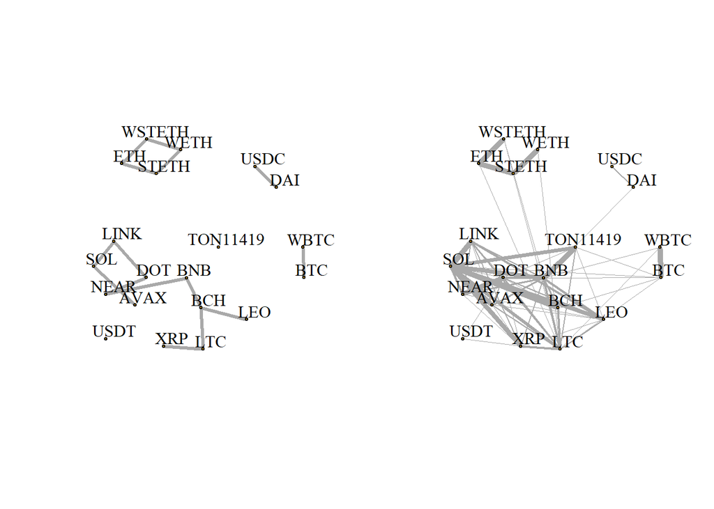

```r
pdf("crypto_mix_plot3_v2.pdf",width = 7,height = 2.5)
par(mfrow=c(1,2),mgp = c(2.2, 0.45, 0),tcl = -0.01, mar = c(0.1, 0.1, 0.6, 0.1))

plot(network_monthly, layout=coords2.2, main="", vertex.label.color="black",
     edge.width=3, vertex.label.dist=1.5, vertex.size=3)

plot(network_whole, layout=coords2.2, main="", vertex.label.color="black",
     edge.width=E(network_whole)$weight,vertex.label.dist=1.5,vertex.size=3)
dev.off()
```

Then, communities are identified using walktrap method

```r
network_monthly_c   <- igraph::cluster_walktrap(network_monthly)
network_whole_c <- igraph::cluster_walktrap(network_whole)
```

and can be plotted (Figure 4 of the manuscript)

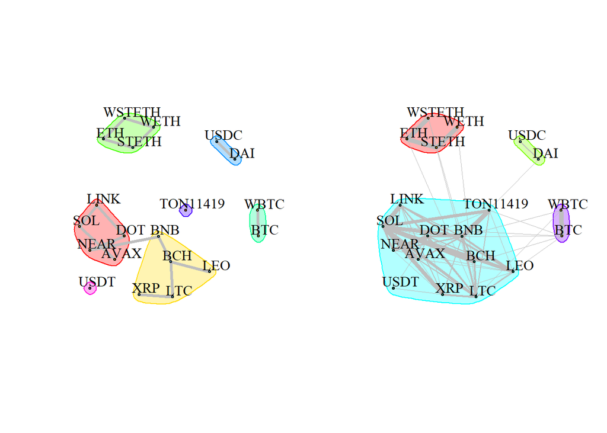

```r
pdf("crypto_mix_walktrap_v2.pdf",width = 7,height = 2.5)
par(mfrow=c(1,2),mgp = c(2.2, 0.45, 0),tcl = -0.01, mar = c(0.1, 0.1, 0.6, 0.1))

plot(network_monthly_c,network_monthly,layout=coords2.2,main="",
     vertex.label.color="black", edge.width=3,vertex.label.dist=1.5,
     vertex.size=3, edge.color = "gray")

plot(network_whole_c,network_whole,layout=coords2.2,main="",
     vertex.label.color="black", edge.width=E(network_whole)$weight,
     vertex.label.dist=1.5,vertex.size=3,edge.color = "gray")
dev.off()
```

The found communities can then be compared

```r
igraph::compare(igraph::cluster_walktrap(network_monthly),
                igraph::cluster_walktrap(network_whole),
                method = "rand")
```

```
## [1] 0.7578947
```